# Revolut_Q2_Q3_Q4

In most of the businesses, user engagement is of utmost importance. In this notbook, I am trying to understand the uder engagement of Revolut sampled data. I am also trying to understand what factors lead to engagement and what will lead to user churn

First import the libraries needed. Install if not already installed, as below:

```python
%%bash -x
pip install --user lifelines
```

[output not shown]

[output not shown]

```python
import pandas as pd
import numpy as np
import seaborn as sns
import matplotlib.pyplot as plt
from scipy import stats
import statsmodels.api as sm
import hdbscan
from pandas.plotting import parallel_coordinates
import prince
import sklearn
from sklearn.feature_selection import RFE
from sklearn import metrics
from sklearn.linear_model import LogisticRegression
from sklearn.svm import SVC, LinearSVC
from sklearn.ensemble import RandomForestClassifier
from sklearn.neighbors import KNeighborsClassifier
from sklearn.naive_bayes import GaussianNB
from sklearn.linear_model import Perceptron
from sklearn.linear_model import SGDClassifier
from sklearn.tree import DecisionTreeClassifier
from sklearn.metrics import confusion_matrix
from sklearn.metrics import classification_report
from sklearn.model_selection import train_test_split
from sklearn.calibration import calibration_curve
from lifelines import CoxPHFitter
from lifelines.utils import median_survival_times, qth_survival_times
```

```python
devices = pd.read_csv('F:\\rev\\rev-devices.csv')
notifications = pd.read_csv('F:\\rev\\rev-notifications.csv')
transactions = pd.read_csv('F:\\rev\\rev-transactions.csv')
users = pd.read_csv('F:\\rev\\rev-users.csv')
```

```python
# resize the notebook
from IPython.core.display import display, HTML
display(HTML("<style>.container { width:100% !important; }</style>"))

# resize the num of columns to be displayed
pd.set_option('display.max_columns', None)
```

```python
# for supressing warnings
import warnings
warnings.filterwarnings("ignore")
```

Then I view the data.

```python
users.head(5)
```

|  | user_id | birth_year | country | city | created_date | user_settings_crypto_unlocked | plan | attributes_notifications_marketing_push | attributes_notifications_marketing_email | num_contacts | num_referrals | num_successful_referrals |
| --- | --- | --- | --- | --- | --- | --- | --- | --- | --- | --- | --- | --- |
| 0 | user_0 | 1989 | PL | Gdansk | 2018-01-13 05:15:15.599466 | 1 | STANDARD | 1.0 | 1.0 | 3 | 0 | 0 |
| 1 | user_1 | 1975 | GB | London | 2018-01-29 03:38:46.676876 | 0 | STANDARD | NaN | NaN | 21 | 0 | 0 |
| 2 | user_2 | 1987 | PL | Poznań | 2018-01-18 19:17:31.229096 | 0 | STANDARD | 0.0 | 0.0 | 21 | 0 | 0 |
| 3 | user_3 | 1994 | FR | Paris | 2018-01-15 18:47:56.723104 | 0 | STANDARD | 1.0 | 0.0 | 0 | 0 | 0 |
| 4 | user_4 | 1985 | GB | Beckenham | 2018-01-11 00:36:46.673673 | 0 | STANDARD | NaN | NaN | 2 | 0 | 0 |

```python
users.info()
```

```
<class 'pandas.core.frame.DataFrame'>
RangeIndex: 19430 entries, 0 to 19429
Data columns (total 12 columns):
user_id                                     19430 non-null object
birth_year                                  19430 non-null int64
country                                     19430 non-null object
city                                        19430 non-null object
created_date                                19430 non-null object
user_settings_crypto_unlocked               19430 non-null int64
plan                                        19430 non-null object
attributes_notifications_marketing_push     12820 non-null float64
attributes_notifications_marketing_email    12820 non-null float64
num_contacts                                19430 non-null int64
num_referrals                               19430 non-null int64
num_successful_referrals                    19430 non-null int64
dtypes: float64(2), int64(5), object(5)
memory usage: 1.8+ MB
```

```python
users.describe()
```

|  | birth_year | user_settings_crypto_unlocked | attributes_notifications_marketing_push | attributes_notifications_marketing_email | num_contacts | num_referrals | num_successful_referrals |
| --- | --- | --- | --- | --- | --- | --- | --- |
| count | 19430.000000 | 19430.000000 | 12820.000000 | 12820.000000 | 19430.000000 | 19430.0 | 19430.0 |
| mean | 1983.648636 | 0.181009 | 0.947582 | 0.895944 | 17.887699 | 0.0 | 0.0 |
| std | 11.368871 | 0.385035 | 0.222877 | 0.305345 | 46.506438 | 0.0 | 0.0 |
| min | 1929.000000 | 0.000000 | 0.000000 | 0.000000 | 0.000000 | 0.0 | 0.0 |
| 25% | 1978.000000 | 0.000000 | 1.000000 | 1.000000 | 0.000000 | 0.0 | 0.0 |
| 50% | 1986.000000 | 0.000000 | 1.000000 | 1.000000 | 5.000000 | 0.0 | 0.0 |
| 75% | 1992.000000 | 0.000000 | 1.000000 | 1.000000 | 19.000000 | 0.0 | 0.0 |
| max | 2001.000000 | 1.000000 | 1.000000 | 1.000000 | 2918.000000 | 0.0 | 0.0 |

Similarly, I view the other three datasets to have initial understanding of the data.

```python
print(users.columns, '\n', transactions.columns, '\n', devices.columns, '\n', notifications.columns)
```

```
Index(['user_id', 'birth_year', 'country', 'city', 'created_date',
       'user_settings_crypto_unlocked', 'plan',
       'attributes_notifications_marketing_push',
       'attributes_notifications_marketing_email', 'num_contacts',
       'num_referrals', 'num_successful_referrals'],
      dtype='object')
 Index(['transaction_id', 'transactions_type', 'transactions_currency',
       'amount_usd', 'transactions_state', 'ea_cardholderpresence',
       'ea_merchant_mcc', 'ea_merchant_city', 'ea_merchant_country',
       'direction', 'user_id', 'created_date'],
      dtype='object')
 Index(['brand', 'user_id'], dtype='object')
 Index(['reason', 'channel', 'status', 'user_id', 'created_date'], dtype='object')
```

Using these, I designed some hypothesis which could impact engagement or churn as follows:

- user generation (H0: user belonging to gen z will be more likely to be engaged)
- country (H0: users from one country are more likely to transact)
- user_settings_crypto_unlocked (H0: users having their crypto setting unlocked are more likely to be engaged)
- plan (H0: users under different plans show different engagement
- num_contact (H0: users having more contacts are more likely to be engaged)
- device type of user (H0: android users are more likely to be engaged)
- transaction direction (H0: users doing more num inbound transactions are more likely to be engaged)
- num notifications sent (H0: more notifications sent will likey attract user to be engaged)
- notification type (H0: different notification type have different impact on user engagement)
- reason (H0: one reason is more significant than other in predicting engagement)

Now I clean the data and create the datasets to be used.

```python
# Drop columns which will not be used
users = users.drop(columns=['city', 'num_referrals', 'num_successful_referrals'])
transactions = transactions.drop(columns=['transactions_currency','ea_merchant_mcc', 'ea_merchant_city', 'ea_merchant_country'])
```

```python
# Handle Dates
users['user_created']= pd.to_datetime(users['created_date']).dt.date
users = users.drop(columns=['created_date'])

transactions['transaction_created']= pd.to_datetime(transactions['created_date']).dt.date
transactions = transactions.drop(columns=['created_date'])

notifications['notif_created']= pd.to_datetime(notifications['created_date']).dt.date
notifications = notifications.drop(columns=['created_date'])

users['users_created_year'] = pd.to_datetime(users['user_created']).dt.year
users['users_created_month'] = pd.to_datetime(users['user_created']).dt.month

transactions['transactions_created_year'] = pd.to_datetime(transactions['transaction_created']).dt.year
transactions['transactions_created_month'] = pd.to_datetime(transactions['transaction_created']).dt.month
```

Clean User data

```python
def binning(col, cut_points, labels=None, minmax=False):
    #Define min and max values:
    if minmax:
        minval = col.min()
        maxval = col.max()

    #create list by adding min and max to cut_points
    try:
        break_points = [minval] + cut_points + [maxval]
    except UnboundLocalError:
        break_points = cut_points

    #if no labels provided, use default labels 0 ... (n-1)
    if not labels:
        labels = range(len(cut_points)+1)

    #Binning using cut function of pandas
    colBin = pd.cut(col,bins=break_points,labels=labels,include_lowest=True)
    return colBin
```

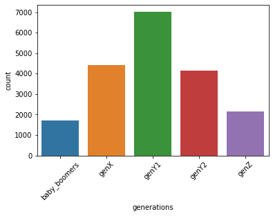

```python
'''
Bin users to various generations
Baby Boomers: 1944 to 1964
Gen X: 1965 - 1979
Gen Y or Millennials: 1980 and 1994
Gen Y.1 = 1980-1990
Gen Y.2 = 1990-1994
Gen Z: 1995 and 2015
'''
#Binning age:
cut_points = [0,1965,1980,1990,1995,2100]
labels = ['baby_boomers','genX','genY1','genY2', 'genZ']
users['generations'] = binning(users['birth_year'], cut_points, labels)
users = users.drop(columns='birth_year')

sns.countplot(x='generations', data=users)
plt.xticks(rotation=45)
```

The genrations follow typical normal distribution

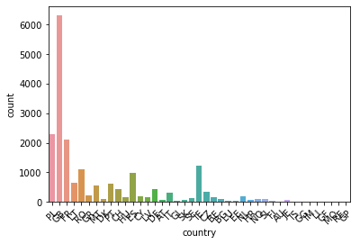

```python
sns.countplot(x='country', data=users)
plt.xticks(rotation=45)
```

```python
# merge user data with devices data
print(len(users))
users = pd.merge(users, devices, on='user_id')
print(len(users))
users.head(2)
```

```
19430
19430
```

|  | user_id | country | user_settings_crypto_unlocked | plan | attributes_notifications_marketing_push | attributes_notifications_marketing_email | num_contacts | user_created | users_created_year | users_created_month | generations | brand |
| --- | --- | --- | --- | --- | --- | --- | --- | --- | --- | --- | --- | --- |
| 0 | user_0 | PL | 1 | STANDARD | 1.0 | 1.0 | 3 | 2018-01-13 | 2018 | 1 | genY1 | Apple |
| 1 | user_1 | GB | 0 | STANDARD | NaN | NaN | 21 | 2018-01-29 | 2018 | 1 | genX | Apple |

I printed out the length of the datasets twice to make sure the sanctity of the data.

```python
# handle notifications data
print(len(notifications))
notifications = notifications[notifications['status']=='SENT']
notifications = notifications.drop(columns='status')
print(len(notifications))
notifications.head(2)
```

```
121813
89477
```

|  | reason | channel | user_id | notif_created |
| --- | --- | --- | --- | --- |
| 0 | REENGAGEMENT_ACTIVE_FUNDS | PUSH | user_7086 | 2018-12-02 |
| 1 | REENGAGEMENT_ACTIVE_FUNDS | PUSH | user_6598 | 2018-12-01 |

```python
# Only completed transactions are considered
print(len(transactions))
transactions = transactions[transactions['transactions_state']=='COMPLETED']
transactions = transactions.drop(columns='transactions_state')
print(len(transactions))
transactions.head(2)
```

```
2740075
2407968
```

|  | transaction_id | transactions_type | amount_usd | ea_cardholderpresence | direction | user_id | transaction_created | transactions_created_year | transactions_created_month |
| --- | --- | --- | --- | --- | --- | --- | --- | --- | --- |
| 0 | transaction_0 | TRANSFER | 4.55 | NaN | OUTBOUND | user_898 | 2018-04-03 | 2018 | 4 |
| 1 | transaction_1 | CARD_PAYMENT | 15.50 | FALSE | OUTBOUND | user_1652 | 2019-03-19 | 2019 | 3 |

Various ways of interpreting the column 'direction' in transactions table

- INBOUND (inter country transaction) and OUTBOUN (intra country transaction)
- INBOUND (money received which doesn't mean user involvement) and OUTBOUND (money sent which signifies user involvement)
- INBOUND (money received when requested by the user or put from the bank or something similar which mean user involvement) and OUTBOUND (money sent which signifies user involvement). This interpretation is considered while analysing the data

Now, let's merge the datasets of users and transactions for identifying the engagement metric

```python
ut = pd.merge(users, transactions, how='outer', on='user_id')
ut.user_id.nunique()
```

```
19430
```

Quality check the merged data

```python
print(len(users), len(transactions), len(ut))
print(sum(transactions.amount_usd)-sum(ut.amount_usd))
```

```
19430 2407968 2408869
nan
```

```python
max_date = max(transactions['transaction_created'])
min_date = min(users.user_created)
print('we have', (max_date - min_date).days, 'days of transaction data from', min_date, 'to', max_date)

overlapping_min = max(users.user_created)
overlapping_max = max(transactions.transaction_created)
print('we have', (overlapping_max - overlapping_min).days, 'days of transaction overlapping between all users from',
     overlapping_min, 'to', overlapping_max)
```

```
we have 499 days of transaction data from 2018-01-01 to 2019-05-15
we have 132 days of transaction overlapping between all users from 2019-01-03 to 2019-05-15
```

Let's consider last 4 months of transacted data for our analysis on seller engagement and get total Transaction Amount (TA) per user per day.

```python
# Method for converting into crosstab
def get_transaction_crosstab(ut_comp, col_x, col_y, col_val, agg_func, drop_all=True):
    data = ut_comp[[col_x, col_y, col_val]]
    data2 = pd.DataFrame(pd.crosstab(data[col_x], data[col_y], values=data[col_val], aggfunc=agg_func, margins=True))
    data2 = data2.drop(columns='All')

    if drop_all:
        try:
            data2 = data2.drop(columns=0)
        except KeyError:
            pass

        # delete the row
        data2 = data2.drop('All')

    data2 = data2.fillna(0)
    return data2

# quality check the data
def get_data_min_max(data):
    dataset_min = min(data.min())
    dataset_max = max(data.max())
    #print(dataset_min)
    #print(dataset_max)
    return dataset_min, dataset_max
```

```python
ut_comp = ut[ut['transaction_created']>overlapping_min]
ut_comp['D'] = (ut_comp.transaction_created-overlapping_min).dt.days

data = get_transaction_crosstab(ut_comp, 'user_id', 'D', 'amount_usd', 'sum')

# check data sanctity
print(get_data_min_max(data))

data.head(5)
```

```
(0.0, 325722.25)
```

| D user_id | 1 | 2 | 3 | 4 | 5 | 6 | 7 | 8 | 9 | 10 | 11 | 12 | 13 | 14 | 15 | 16 | 17 | 18 | 19 | 20 | 21 | 22 | 23 | 24 | 25 | 26 | 27 | 28 | 29 | … |
| --- | --- | --- | --- | --- | --- | --- | --- | --- | --- | --- | --- | --- | --- | --- | --- | --- | --- | --- | --- | --- | --- | --- | --- | --- | --- | --- | --- | --- | --- | --- |
| user_0 | 0.00 | 0.0 | 0.0 | 0.00 | 0.00 | 0.00 | 0.00 | 0.00 | 0.00 | 0.00 | 0.0 | 0.00 | 0.00 | 0.00 | 0.00 | 0.00 | 0.00 | 0.00 | 0.00 | 0.00 | 0.0 | 0.00 | 0.0 | 0.00 | 1.19 | 1.99 | 0.00 | 0.0 | 0.00 | … |
| user_1 | 0.00 | 0.0 | 0.0 | 0.00 | 0.00 | 0.00 | 0.00 | 0.00 | 0.00 | 0.00 | 0.0 | 0.00 | 0.00 | 0.00 | 0.00 | 0.00 | 0.00 | 0.00 | 225.00 | 250.00 | 0.0 | 0.00 | 0.0 | 0.00 | 0.00 | 0.00 | 0.00 | 0.0 | 0.00 | … |
| user_10 | 383.82 | 0.0 | 0.0 | 0.00 | 40.85 | 187.25 | 13.62 | 8.51 | 47.67 | 17.87 | 116.6 | 22.13 | 27.24 | 68.78 | 0.00 | 0.00 | 0.00 | 0.00 | 17.02 | 48.51 | 0.0 | 30.64 | 0.0 | 181.27 | 85.96 | 0.00 | 0.00 | 0.0 | 348.93 | … |
| user_100 | 0.00 | 0.0 | 0.0 | 0.00 | 0.00 | 0.00 | 0.00 | 0.00 | 0.00 | 0.00 | 0.0 | 0.00 | 0.00 | 0.00 | 154.42 | 0.00 | 531.92 | 0.00 | 0.00 | 0.00 | 0.0 | 0.00 | 0.0 | 0.00 | 0.00 | 0.00 | 77.51 | 0.0 | 5.01 | … |
| user_10000 | 0.00 | 0.0 | 0.0 | 293.16 | 0.00 | 0.00 | 0.00 | 0.00 | 0.00 | 0.00 | 0.0 | 0.00 | 0.00 | 0.00 | 0.00 | 422.23 | 0.00 | 1133.94 | 0.00 | 0.00 | 0.0 | 0.00 | 0.0 | 0.00 | 0.00 | 0.00 | 0.00 | 0.0 | 0.00 | … |

```python
print(notifications.shape)
notifications = notifications[notifications['notif_created']>overlapping_min]
print(notifications.shape)
```

```
(89477, 4)
(40227, 4)
```

Now we have our datasets created:

- users (merged with users)
- transactions
- notifications
- data (crosstab of users and transactions in last D days)  
  Let's remove outliers using z-test

```python
z = np.abs(stats.zscore(data))
threshold = 3
data_o = data[(z < threshold).all(axis=1)]
print(len(data_o))
data_o.describe()
```

```
11771
```

| D | 1 | 2 | 3 | 4 | 5 | 6 | 7 | 8 | 9 | 10 | 11 | 12 | 13 | 14 | 15 | 16 | 17 | 18 | 19 | 20 | 21 | 22 | 23 | 24 | 25 | 26 | 27 | 28 | 29 | … |
| --- | --- | --- | --- | --- | --- | --- | --- | --- | --- | --- | --- | --- | --- | --- | --- | --- | --- | --- | --- | --- | --- | --- | --- | --- | --- | --- | --- | --- | --- | --- |
| count | 11771.000000 | 11771.000000 | 11771.000000 | 11771.000000 | 11771.000000 | 11771.000000 | 11771.000000 | 11771.000000 | 11771.000000 | 11771.000000 | 11771.000000 | 11771.000000 | 11771.000000 | 11771.000000 | 11771.000000 | 11771.000000 | 11771.000000 | 11771.000000 | 11771.000000 | 11771.000000 | 11771.000000 | 11771.000000 | 11771.000000 | 11771.000000 | 11771.000000 | 11771.000000 | 11771.000000 | 11771.000000 | 11771.000000 | … |
| mean | 12.564488 | 16.187546 | 9.198402 | 8.113334 | 10.243975 | 9.610414 | 10.005930 | 11.567431 | 11.754593 | 8.898248 | 8.159908 | 12.051151 | 11.247746 | 10.913486 | 11.049710 | 12.155280 | 9.342404 | 6.749028 | 10.366241 | 10.935489 | 11.771612 | 12.210258 | 15.522849 | 11.332608 | 10.542527 | 12.167998 | 12.466294 | 14.331155 | 15.775519 | … |
| std | 64.936974 | 109.433708 | 42.484109 | 40.558178 | 56.182376 | 50.055526 | 52.870208 | 62.761716 | 58.850865 | 41.341464 | 42.196522 | 80.905318 | 75.489550 | 71.501845 | 60.430902 | 60.353261 | 42.532415 | 34.129063 | 55.301183 | 68.001207 | 75.706805 | 63.550808 | 80.144820 | 52.726993 | 57.741958 | 72.337364 | 80.515875 | 83.478029 | 86.881015 | … |
| min | 0.000000 | 0.000000 | 0.000000 | 0.000000 | 0.000000 | 0.000000 | 0.000000 | 0.000000 | 0.000000 | 0.000000 | 0.000000 | 0.000000 | 0.000000 | 0.000000 | 0.000000 | 0.000000 | 0.000000 | 0.000000 | 0.000000 | 0.000000 | 0.000000 | 0.000000 | 0.000000 | 0.000000 | 0.000000 | 0.000000 | 0.000000 | 0.000000 | 0.000000 | … |
| 25% | 0.000000 | 0.000000 | 0.000000 | 0.000000 | 0.000000 | 0.000000 | 0.000000 | 0.000000 | 0.000000 | 0.000000 | 0.000000 | 0.000000 | 0.000000 | 0.000000 | 0.000000 | 0.000000 | 0.000000 | 0.000000 | 0.000000 | 0.000000 | 0.000000 | 0.000000 | 0.000000 | 0.000000 | 0.000000 | 0.000000 | 0.000000 | 0.000000 | 0.000000 | … |
| 50% | 0.000000 | 0.000000 | 0.000000 | 0.000000 | 0.000000 | 0.000000 | 0.000000 | 0.000000 | 0.000000 | 0.000000 | 0.000000 | 0.000000 | 0.000000 | 0.000000 | 0.000000 | 0.000000 | 0.000000 | 0.000000 | 0.000000 | 0.000000 | 0.000000 | 0.000000 | 0.000000 | 0.000000 | 0.000000 | 0.000000 | 0.000000 | 0.000000 | 0.000000 | … |
| 75% | 0.000000 | 0.000000 | 0.000000 | 0.000000 | 0.000000 | 0.000000 | 0.000000 | 0.000000 | 0.000000 | 0.000000 | 0.000000 | 0.000000 | 0.000000 | 0.000000 | 0.000000 | 0.000000 | 0.000000 | 0.000000 | 0.000000 | 0.000000 | 0.000000 | 0.000000 | 0.000000 | 0.000000 | 0.000000 | 0.000000 | 0.000000 | 0.000000 | 0.000000 | … |
| max | 1375.850000 | 5414.580000 | 604.260000 | 612.760000 | 1040.370000 | 873.770000 | 953.160000 | 1230.000000 | 1041.250000 | 661.880000 | 800.000000 | 2769.450000 | 2546.960000 | 2487.540000 | 1174.530000 | 1093.710000 | 738.440000 | 596.500000 | 1010.000000 | 2500.000000 | 2950.270000 | 1114.890000 | 1741.210000 | 867.320000 | 1218.220000 | 1702.120000 | 2602.700000 | 2208.970000 | 1723.220000 | … |

```python
data_eng = data_o[data_o.iloc[:, -50:].sum(axis = 1) > 0]
len(data_eng)
```

```
9395
```

Let's remove noise (take average of last 'd' number of days) and scalarize the data between 0 to 1. For determining 'd', let's analise frequency of the transactions or session interval.

session_interval = average time spent between two transactions

```python
def session_interval_df(ut_comp, data_eng):
    ut = ut_comp[ut_comp['user_id'].isin(data_eng.index)]
    ut_sorted = ut.sort_values(['user_id', 'transaction_created'], ascending=[True, True]).reset_index(drop=True)
    data = ut_sorted[['user_id', 'transaction_created', 'amount_usd']]

    data['user_id_shift'] = data['user_id'].shift(1) # not necessary, will be faster
    data['transaction_created_shift'] = data['transaction_created'].shift(1)

    data['time_diff'] = np.where(data['user_id_shift']==data['user_id'], (data['transaction_created']-data['transaction_created_shift']).dt.days, 0)

    return data

si_data = session_interval_df(ut_comp, data_eng)

si_data_total = si_data[['user_id', 'time_diff']].describe()
print(si_data_total)
print('=> mean of the time difference for the whole data (between two transactions) is', si_data_total.loc['mean'].values[0], 'days')
print()

si_data_within = si_data[['user_id', 'time_diff']].groupby('user_id').mean().describe()
print(si_data_within)
print('=> mean of users'' mean time difference, i.e. mean within groups (groups being users) is', si_data_within.loc['mean'].values[0], 'days')

# Let's take d as:
d = int(si_data_within.loc['mean'].values[0])
```

```
           time_diff
count  662884.000000
mean        1.300393
std         4.671552
min         0.000000
25%         0.000000
50%         0.000000
75%         1.000000
max       126.000000
=> mean of the time difference for the whole data (between two transactions) is 1.3003934323350692 days

         time_diff
count  9395.000000
mean      4.152293
std       5.678992
min       0.000000
25%       0.937500
50%       2.243243
75%       5.000000
max      63.000000
=> mean of users mean time difference, i.e. mean within groups (groups being users) is 4.152292693980626 days
```

```python
# methods to remove noise and scalarize the data
def remove_noise(df, n=5):
    df_cumsum = df.cumsum(axis=1)
    df_cumsum2 = df_cumsum.shift(periods=n,axis=1).fillna(0)#,fill_value=0)
    chk = df_cumsum-df_cumsum2
    for i in range(1,n-1):
        chk[i] = df[i]
    return chk

def scalarize_data(dataset):
    dataset_min = min(dataset.min())
    dataset_max = max(dataset.max())
    dataNorm=((dataset-dataset_min)/(dataset_max-dataset_min))
    return dataNorm

def num_engaged_users(scalar_data, val):
    engaged_users = []
    for column in scalar_data:
        engaged_users.append(len(scalar_data[(scalar_data[column]>val)]))#.count())
    tot = sum(engaged_users)
    print('Num users*days considered engaged with threshold', val, ':', tot)#.count())
    return engaged_users

def num_engaged_days_users(scalar_data):
    for val in range(0,10,1):
        i = 0
        for column in scalar_data:
            if scalar_data[column].max()>val/10:
                i += 1
        print('threshold=', val/10, 'Num days where there''s engagement:',i)
        num_engaged_users(scalar_data, val/10)
        i = 0
    for column in scalar_data:
        if scalar_data[column].max()>0.05:
            i += 1
    print('threshold=', 0.05, 'Num days where there''s engagement:', i)
    num_engaged_users(scalar_data, 0.5)
```

From the crosstab having Transaction Amount (TA) per day per user, clean the data removing noise (by taking average of last 4 days) followed by rescaling it between 0 to 1. We have our final metric as Scaled TA (STA) which is considered for engagement analysis.

```python
scalar_data = scalarize_data(remove_noise(data_eng, n=int(d)))
scalar_data = scalar_data*100
scalar_data = scalar_data.round(2)

print(get_data_min_max(scalar_data))

num_engaged_days_users(scalar_data)
```

```
(0.0, 100.0)
threshold= 0.0 Num days where theres engagement: 132
Num users*days considered engaged with threshold 0.0 : 496662
threshold= 0.1 Num days where theres engagement: 132
Num users*days considered engaged with threshold 0.1 : 433519
threshold= 0.2 Num days where theres engagement: 132
Num users*days considered engaged with threshold 0.2 : 387112
threshold= 0.3 Num days where theres engagement: 132
Num users*days considered engaged with threshold 0.3 : 353630
threshold= 0.4 Num days where theres engagement: 132
Num users*days considered engaged with threshold 0.4 : 328311
threshold= 0.5 Num days where theres engagement: 132
Num users*days considered engaged with threshold 0.5 : 307239
threshold= 0.6 Num days where theres engagement: 132
Num users*days considered engaged with threshold 0.6 : 289302
threshold= 0.7 Num days where theres engagement: 132
Num users*days considered engaged with threshold 0.7 : 271606
threshold= 0.8 Num days where theres engagement: 132
Num users*days considered engaged with threshold 0.8 : 258897
threshold= 0.9 Num days where theres engagement: 132
Num users*days considered engaged with threshold 0.9 : 245181
threshold= 0.05 Num days where theres engagement: 132
Num users*days considered engaged with threshold 0.5 : 307239
```

Reasoning behind selection of the engagement metric:

- Business -> considered transaction volume, as with increase in transaction volume i.e. amount, users' increased trust could be inferred. Transaction amount of the completed transactions is considered
- Normalized -> use currency convertor on the transaction amount. Not required as amount_usd is given
- Remove noise -> take average of last d num of days (instead of avg, sum is taken, as anyway we are rescaling the data)
- Rescaled -> rescaled data, so make it stable

For calibrating engagement at daily level, STA can be considered. Let's say engaged users are STA>0.75 and unengaged users are STA<0.25 which is determined at daily level. In order to calculate long term engagement, let's carry out cluster analysis on the crosstab data.

Let's implement clustering to identify different groups. For clustering, I prefer density based clustering, as it doesn't require num of clusters and is shape independent. It works well in high dimensional space.  
In this case, I have used HDBSCAN for clustering. And canberra distance metric. For high dimensional data, refer:  
Shirkhorshidi, A.S., Aghabozorgi, S. and Wah, T.Y., 2015. A comparison study on similarity and dissimilarity measures in clustering continuous data. PloS one, 10(12), p.e0144059.  
The only hyper-parameter to be handled is the min num of points in a cluster. It also gives probability of assining a data point to a cluster. It also handles noise, since all the points are not assigned to a cluster.

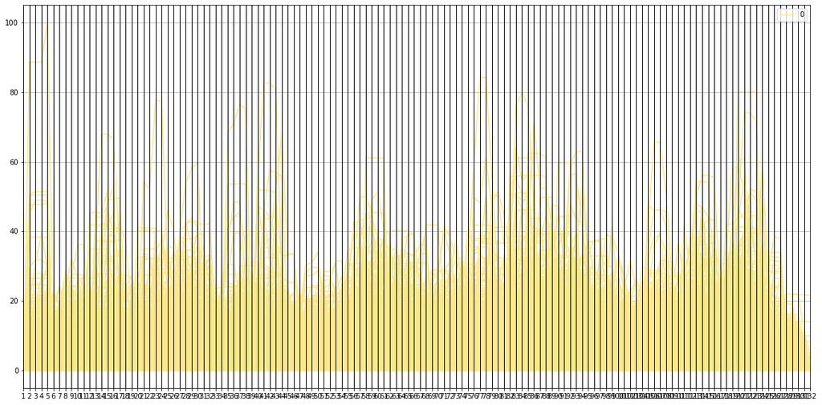

```python
# Parallel coordinates data for all the users
scalar_data['default'] = 0
plt.rcParams["figure.figsize"] = (20,10)
pc = parallel_coordinates(scalar_data, 'default', color=('#FFE888'))
```

```python
# Make clusters
def hdbscan_clusters(hdbscan_data, cluster_size=100, var=10):
    clusterer = hdbscan.HDBSCAN(metric='canberra', min_cluster_size=cluster_size)
    #clusterer.fit(hdbscan_data.iloc[:, -(var+rnd):-rnd]) # take random columns
    clusterer.fit(hdbscan_data.iloc[:, -var:]) # take random columns
    return clusterer.labels_.max()+1, clusterer.labels_, clusterer.probabilities_
```

```python
# for fitting the clusters, take last 45 days (1.5 month) of data
num_clusters, labels, probabs = hdbscan_clusters(scalar_data.drop(columns='default'), cluster_size=50, var=45)
print('total num of clusters:', num_clusters)
print('Cluster frequency')
print(stats.itemfreq(labels))
```

```
total num of clusters: 6
Cluster frequency
[[  -1 8625]
 [   0  202]
 [   1   59]
 [   2  262]
 [   3   72]
 [   4  122]
 [   5   53]]
```

-1 are the outliers, which couldn't fit well to any group. Let's now view the clusters

```python
cluster = pd.DataFrame()
cluster = cluster.reindex(scalar_data.index)
cluster['groups'] = labels.tolist()

# Let's plot for last 45 days
par_cor = pd.concat([scalar_data.drop(columns='default').iloc[:, -45:], cluster['groups']], axis=1)
plt.rcParams["figure.figsize"] = (20,5)
```

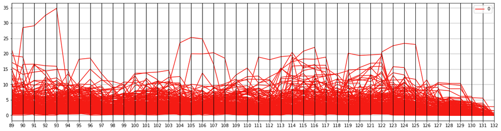

```python
plt.rcParams["figure.figsize"] = (20,5)
parallel_coordinates(par_cor[par_cor['groups']==0].iloc[:,-45:].iloc[:,-45:], 'groups', color=('#f51b14'))
```

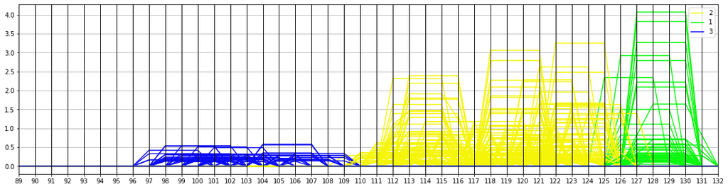

```python
parallel_coordinates(par_cor[par_cor['groups'].isin([1,2,3])].iloc[:,-45:], 'groups', color=('#f5f507', '#0af70e', '#0a0af7'))
```

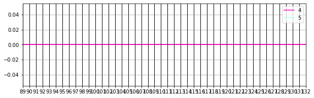

```python
plt.rcParams["figure.figsize"] = (10,3)
parallel_coordinates(par_cor[par_cor['groups'].isin([4,5])].iloc[:,-45:], 'groups', color=('#f507c1', '#b0fff8'))
```

Looking at the above results and the three plots, a clear structure in the data could be seen:  
group 0: Long term Engaged users  
group 1,2,3: Irregularly Engaged users  
group 4,5: Long term non-engaged users

let's check if the difference between the groups is statistically significant

```python
f_val, p_val = stats.f_oneway(par_cor[par_cor['groups']==0].iloc[:,-45:], par_cor[par_cor['groups'].isin([4,5])].iloc[:,-45:])
print('p val for anova for Long term engaged vs Long term non-engaged:', p_val)

f_val, p_val = stats.f_oneway(par_cor[par_cor['groups']==0].iloc[:,-45:], par_cor[par_cor['groups'].isin([1,2,3])].iloc[:,-45:])
print('p val for anova for Long term engaged vs Irregularly Engaged:', p_val)

f_val, p_val = stats.f_oneway(par_cor[par_cor['groups'].isin([4,5])].iloc[:,-45:], par_cor[par_cor['groups'].isin([1,2,3])].iloc[:,-45:])
print('p val for anova for Long term non-engaged vs Irregularly Engaged:', p_val)
```

```
p val for anova for Long term engaged vs Long term non-engaged: [3.83180075e-039 4.51498742e-037 6.58258602e-034 1.29205079e-029
 3.30235938e-034 2.85078670e-054 4.36394882e-053 1.19514295e-047
 8.23294363e-048 1.79924560e-044 5.20775015e-045 5.79873966e-043
 8.30757045e-052 4.84651643e-051 2.54526133e-052 2.33300192e-041
 1.33652527e-032 4.54799418e-036 1.39781989e-046 7.94921735e-052
 5.47105218e-046 4.92354969e-040 1.98583809e-036 7.43680308e-037
 4.53356223e-036 7.54268152e-035 4.19294660e-037 4.50919255e-037
 3.39001992e-040 5.20700404e-045 1.37576572e-037 1.18608022e-037
 3.87836369e-037 7.54742871e-037 6.48649222e-042 4.81209265e-037
 8.85111438e-032 8.30514243e-032 1.03201092e-031 2.51584645e-028
 1.54428563e-026 3.97847165e-022 9.16391016e-010 2.51713857e-002
 2.57618476e-317]
p val for anova for Long term engaged vs Irregularly Engaged: [1.60080655e-079 1.73828706e-075 2.82268401e-069 9.36637791e-061
 7.24666931e-070 2.37343514e-108 3.94160185e-106 7.29230146e-096
 5.06924552e-096 4.06594222e-089 5.45908922e-090 7.93410135e-086
 1.36526289e-102 1.68681020e-101 6.17573518e-104 4.15204051e-083
 4.94850613e-066 8.46089581e-073 4.31492693e-093 2.30522877e-103
 1.59796837e-092 6.12105397e-081 1.78390177e-073 6.32383680e-072
 2.83545720e-068 8.61643186e-067 4.98727048e-071 1.34619680e-072
 9.63390245e-080 8.73274001e-084 9.18417715e-071 2.97222728e-069
 6.52305832e-068 1.31247308e-068 9.94195581e-077 3.50775501e-069
 1.14032421e-059 5.24355013e-061 3.74412026e-054 1.48092939e-046
 4.05583782e-043 8.57495188e-033 4.01252020e-019 7.95587625e-004
 4.79609872e-215]
p val for anova for Long term non-engaged vs Irregularly Engaged: [3.04512388e-087 3.04512388e-087 3.04512388e-087 3.04512388e-087
 3.04512388e-087 3.04512388e-087 3.04512388e-087 3.04512388e-087
 2.15645251e-001 1.03818988e-002 3.06271327e-003 1.91616356e-004
 1.00986491e-004 9.14253952e-004 1.14094648e-003 3.30827793e-003
 1.95235869e-003 1.15915926e-003 2.93836418e-003 1.47333558e-002
 1.10573860e-001 2.73847765e-002 2.86264809e-003 3.14424990e-004
 1.17875238e-005 5.24338557e-006 6.71644112e-006 1.35862113e-004
 7.50036681e-004 3.43358938e-005 1.31102637e-005 6.69664389e-007
 1.47541510e-007 6.96449696e-007 1.09733773e-006 1.56128044e-005
 4.73235715e-004 7.40782090e-003 1.40866563e-003 1.48824661e-003
 1.93236777e-003 9.90169172e-003 1.70833622e-001 3.04512388e-087
 5.65350726e-193]
```

Now that we have engaged and unengaged users, let's build a model. It is a typical binary classification problem

Prepare user data for Logistic Regression

```python
def get_model_df(users):
    par_cor['user_id'] = par_cor.index

    data = pd.merge(ut_comp, par_cor['groups'], on='user_id')
    u = pd.merge(users, par_cor['groups'], on='user_id')

    a = data[(overlapping_max-data['transaction_created']).dt.days>30].groupby(['user_id', 'direction'])['transaction_id'].count().unstack()
    b = notifications[(overlapping_max-notifications['notif_created']).dt.days>30].groupby(['user_id'])['notif_created'].count()
    d = notifications[(overlapping_max-notifications['notif_created']).dt.days>30].groupby(['user_id', 'reason'])['notif_created'].count().unstack()

    u = pd.merge(u, pd.DataFrame(a['INBOUND']-a['OUTBOUND']), on='user_id', how='left')

    u = pd.merge(u, pd.DataFrame(b).notif_created, on='user_id', how='left') # rename column

    for col in d.columns:
        u = pd.merge(u, d[col], on='user_id', how='left')

    u = u.rename(columns={0: 'inbound_outbound_diff_1M', 'EMAIL':'num_notif_email_1M',
                                        'PUSH':'num_notif_push_1M', 'notif_created':'num_notif_1M'})
    u = u.drop(columns=['user_created', 'users_created_year', 'users_created_month'])
    u = u.replace({'groups': {2:1, 3: 1}}) # Irregular engaged
    u = u.replace({'groups': {4:2, 5: 2}}) # Unengaged

    for c in u.columns:
        try:
            u[c] = u[c].fillna(0)
        except ValueError:
            u[c] = u[c].cat.add_categories('Unknown')
            u[c] = u[c].fillna('Unknown', inplace =True)

    u['generations'] = users['generations']

    return u
```

```python
users_df = get_model_df(users)
users_df.shape
```

```
(9395, 25)
```

```python
users_df.columns
```

```
Index(['user_id', 'country', 'user_settings_crypto_unlocked', 'plan',
       'attributes_notifications_marketing_push',
       'attributes_notifications_marketing_email', 'num_contacts',
       'generations', 'brand', 'groups', 'inbound_outbound_diff_1M',
       'num_notif_1M', 'ENGAGEMENT_SPLIT_BILL_RESTAURANT',
       'FIFTH_PAYMENT_PROMO', 'JOINING_ANNIVERSARY', 'LOST_CARD_ORDER',
       'MADE_MONEY_REQUEST_NOT_SPLIT_BILL', 'METAL_GAME_START',
       'NO_INITIAL_CARD_ORDER', 'NO_INITIAL_CARD_USE',
       'NO_INITIAL_FREE_PROMOPAGE_CARD_ORDER',
       'ONBOARDING_TIPS_ACTIVATED_USERS', 'PREMIUM_ENGAGEMENT_FEES_SAVED',
       'REENGAGEMENT_ACTIVE_FUNDS', 'WELCOME_HOME'],
      dtype='object')
```

```python
features1 = ['num_contacts', 'inbound_outbound_diff_1M']
features2 = ['user_settings_crypto_unlocked', 'plan', 'attributes_notifications_marketing_push', 'attributes_notifications_marketing_email',
             'generations', 'brand', 'num_notif_1M',
       'ENGAGEMENT_SPLIT_BILL_RESTAURANT', 'FIFTH_PAYMENT_PROMO',
       'JOINING_ANNIVERSARY', 'LOST_CARD_ORDER',
       'MADE_MONEY_REQUEST_NOT_SPLIT_BILL', 'METAL_GAME_START',
       'NO_INITIAL_CARD_ORDER', 'NO_INITIAL_CARD_USE',
       'NO_INITIAL_FREE_PROMOPAGE_CARD_ORDER',
       'ONBOARDING_TIPS_ACTIVATED_USERS', 'PREMIUM_ENGAGEMENT_FEES_SAVED',
       'REENGAGEMENT_ACTIVE_FUNDS', 'WELCOME_HOME']
print(len(features1)+len(features2))
```

```
22
```

```python
model_df = users_df[users_df['groups'].isin([0,2])]
model_df.shape
```

```
(377, 25)
```

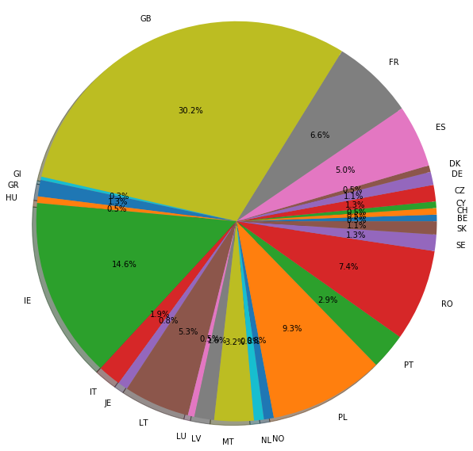

```python
# for countries
labels = model_df['country'].astype('category').cat.categories.tolist()
counts = model_df['country'].value_counts()
sizes = [counts[var_cat] for var_cat in labels]
fig1, ax1 = plt.subplots(figsize=(10,10))
ax1.pie(sizes, labels=labels, autopct='%1.1f%%', shadow=True) #autopct is show the % on plot
ax1.axis('equal')
plt.show()
```

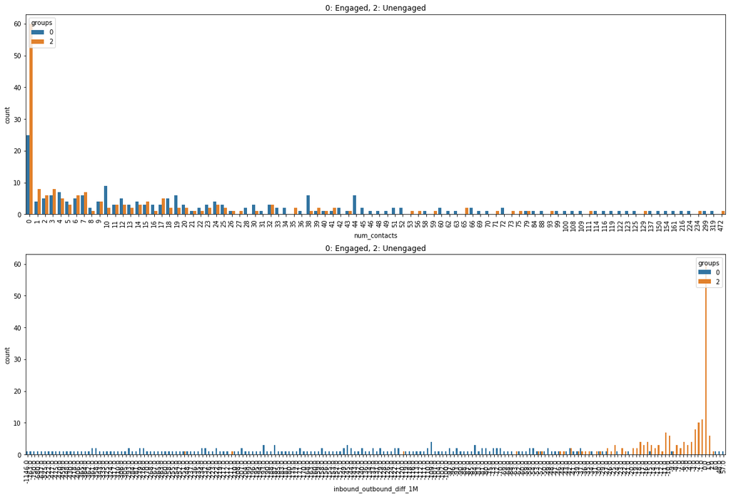

```python
fig=plt.subplots(figsize=(20,20))
for i, j in enumerate(features1):
    plt.subplot(3, 1, i+1)
    # plt.subplots_adjust(hspace = 1.0)
    sns.countplot(x=j, data=model_df, hue='groups')
    plt.xticks(rotation=90)
    plt.title("0: Engaged, 2: Unengaged")
```

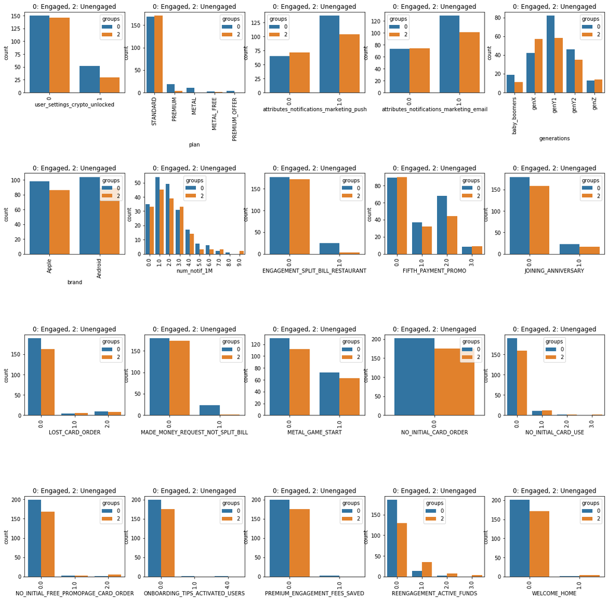

```python
fig=plt.subplots(figsize=(20,20))
for i, j in enumerate(features2):
    plt.subplot(4, 5, i+1)
    plt.subplots_adjust(hspace = 1.0)
    sns.countplot(x=j, data=model_df, hue='groups')
    plt.xticks(rotation=90)
    plt.title("0: Engaged, 2: Unengaged")
```

```python
def cat_data_handling(model_df):
    model_df['android_users'] = model_df['brand'].apply(lambda x: 1 if x=='Android' else 0)

    age_group = pd.get_dummies(model_df['generations'], prefix='age_grp')
    model_df = pd.concat([model_df, age_group], axis=1)

    plan_df = pd.get_dummies(model_df['plan'], prefix='plan')
    model_df = pd.concat([model_df, plan_df], axis=1)

    model_df = model_df.drop(columns=['brand', 'generations', 'plan'])

    model_df['country'] = model_df['country'].astype('category').cat.codes

    model_df['groups'] = model_df['groups'].apply(lambda x: 1 if x==2 else 0)

    return model_df

def quality_check_model_data(model_df):
    for col in model_df.columns:
        chk = model_df[pd.notnull(model_df[col])]
        if chk.shape != model_df.shape:
            yield(col)

model_data = cat_data_handling(model_df)
print(list(quality_check_model_data(model_data)) if list(quality_check_model_data(model_data)) else None) # should return None

model_data.shape
```

```
None
```

```
(377, 33)
```

```python
X = model_data.drop(columns=['user_id', 'groups'])
y = model_data['groups']

def feature_selection(X, y, num_features):
    logreg = LogisticRegression()
    rfe = RFE(logreg, num_features) # reduce the num of features to half
    rfe = rfe.fit(X, y.values.ravel())
    #print(rfe.support_)
    #print(rfe.ranking_)

    # get relevant columns
    def get_rel_col(rfe, rel_col = []):
        i = 0
        for c in rfe.support_:
            if c:
                rel_col.append(list(X)[i])
            i += 1
        return rel_col

    X=model_data[get_rel_col(rfe)]

    logit_model=sm.Logit(y, X)
    result=logit_model.fit(maxiter=30)
    print('for', num_features, 'num of features, model results are')
    print(result.summary2())

    return X
```

```python
for i in range(10, 25, 4):
    feature_selection(X, y, num_features=i)
```

```
Warning: Maximum number of iterations has been exceeded.
         Current function value: 0.573243
         Iterations: 30
for 10 num of features, model results are
                                                  Results: Logit
===================================================================================================================
Model:                                Logit                            Pseudo R-squared:                 0.170
Dependent Variable:                   groups                           AIC:                              452.2255
Date:                                 2019-12-10 18:33                 BIC:                              491.5480
No. Observations:                     377                              Log-Likelihood:                   -216.11
Df Model:                             9                                LL-Null:                          -260.35
Df Residuals:                         367                              LLR p-value:                      3.2963e-15
Converged:                            0.0000                           Scale:                            1.0000
No. Iterations:                       30.0000
-------------------------------------------------------------------------------------------------------------------
                                      Coef.        Std.Err.        z    P>|z|        [0.025             0.975]
-------------------------------------------------------------------------------------------------------------------
ENGAGEMENT_SPLIT_BILL_RESTAURANT      -2.5022            0.7130 -3.5097 0.0004            -3.8996           -1.1049
LOST_CARD_ORDER                       -0.9079            0.4151 -2.1871 0.0287            -1.7216           -0.0943
MADE_MONEY_REQUEST_NOT_SPLIT_BILL     -2.7673            0.7704 -3.5920 0.0003            -4.2773           -1.2573
NO_INITIAL_CARD_USE                    0.9399            0.5316  1.7681 0.0770            -0.1020            1.9817
NO_INITIAL_FREE_PROMOPAGE_CARD_ORDER   0.7526            0.4785  1.5728 0.1158            -0.1853            1.6905
REENGAGEMENT_ACTIVE_FUNDS              1.2916            0.3034  4.2574 0.0000             0.6970            1.8862
WELCOME_HOME                           1.8670            1.3310  1.4027 0.1607            -0.7417            4.4758
age_grp_genY1                         -0.5988            0.2368 -2.5287 0.0114            -1.0629           -0.1347
plan_METAL                           -52.4367 105068256495.3565 -0.0000 1.0000 -205929998701.7520 205929998596.8786
plan_STANDARD                          0.2184            0.1593  1.3713 0.1703            -0.0938            0.5305
===================================================================================================================

Warning: Maximum number of iterations has been exceeded.
         Current function value: 0.556049
         Iterations: 30
for 14 num of features, model results are
                                          Results: Logit
==================================================================================================
Model:                         Logit                       Pseudo R-squared:            0.195
Dependent Variable:            groups                      AIC:                         447.2607
Date:                          2019-12-10 18:33            BIC:                         502.3121
No. Observations:              377                         Log-Likelihood:              -209.63
Df Model:                      13                          LL-Null:                     -260.35
```

[output cut: 84 more lines]

```
MADE_MONEY_REQUEST_NOT_SPLIT_BILL         13.0404      20706.1652  0.0006 0.9995      -40570.2976      40596.3784
METAL_GAME_START                          15.0037      20706.1651  0.0007 0.9994      -40568.3342      40598.3417
NO_INITIAL_CARD_USE                       16.4318      20706.1652  0.0008 0.9994      -40566.9062      40599.7697
NO_INITIAL_FREE_PROMOPAGE_CARD_ORDER      17.1346      20706.1652  0.0008 0.9993      -40566.2034      40600.4726
REENGAGEMENT_ACTIVE_FUNDS                 17.0381      20706.1651  0.0008 0.9993      -40566.2999      40600.3760
WELCOME_HOME                              17.2293      20706.1652  0.0008 0.9993      -40566.1087      40600.5673
age_grp_genX                               1.1744          0.7662  1.5327 0.1253          -0.3274          2.6761
age_grp_genY1                              0.5667          0.7434  0.7623 0.4459          -0.8903          2.0237
age_grp_genY2                              0.9114          0.8105  1.1244 0.2608          -0.6773          2.5000
age_grp_genZ                               1.5079          1.2525  1.2039 0.2286          -0.9469          3.9627
plan_METAL                               -19.7320       2860.3078 -0.0069 0.9945       -5625.8323       5586.3682
plan_METAL_FREE                            9.3622         55.3149  0.1693 0.8656         -99.0529        117.7774
plan_PREMIUM_OFFER                       -38.0230 1008835121.4165 -0.0000 1.0000 -1977280542.3385 1977280466.2925
plan_STANDARD                              2.7612          0.6964  3.9651 0.0001           1.3963          4.1261
=================================================================================================================
```

Looking at the p-values, select the columns (with p-val <0.05) to be considered for modelling and do a train test split

```python
model_cols = ['attributes_notifications_marketing_push', 'num_notif_1M', 'ENGAGEMENT_SPLIT_BILL_RESTAURANT', 'MADE_MONEY_REQUEST_NOT_SPLIT_BILL',
              'NO_INITIAL_CARD_USE', 'age_grp_genY1', 'REENGAGEMENT_ACTIVE_FUNDS', 'plan_STANDARD']


X=model_data[model_cols]

X_train, X_test, y_train, y_test = train_test_split(X, y, test_size=0.3, random_state=42)

# Fit the model
logreg = LogisticRegression()
logreg.fit(X_train, y_train)
y_pred = logreg.predict(X_test)

def get_acc_prec_rec(y_test, y_pred):

    # Model Accuracy, how often is the classifier correct?
    acc = str(round(metrics.accuracy_score(y_test, y_pred)* 100, 2)) + '%'

    # Model Precision
    prec = str(round(metrics.precision_score(y_test, y_pred)* 100, 2)) + '%'

    # Model Recall
    rec = str(round(metrics.recall_score(y_test, y_pred)* 100, 2)) + '%'

    return acc, prec, rec

acc, prec, recall = get_acc_prec_rec(y_test, y_pred)

print('Accuracy of the Logistic regression model is', acc)
```

```
Accuracy of the Logistic regression model is 60.53%
```

Let's plot AUC as well. This is similar to concordance

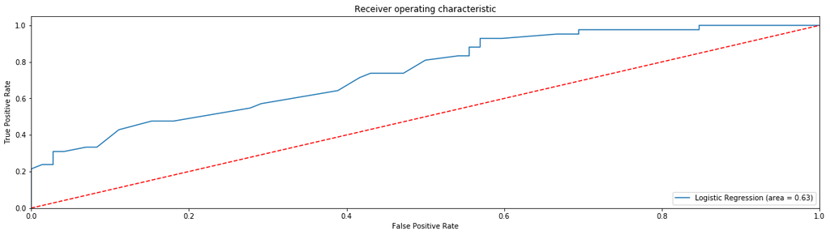

```python
from sklearn.metrics import roc_auc_score, roc_curve
logit_roc_auc = roc_auc_score(y_test, logreg.predict(X_test))
fpr, tpr, thresholds = roc_curve(y_test, logreg.predict_proba(X_test)[:,1])
plt.figure(figsize=(20, 5))
plt.plot(fpr, tpr, label='Logistic Regression (area = %0.2f)' % logit_roc_auc)
plt.plot([0, 1], [0, 1],'r--')
plt.xlim([0.0, 1.0])
plt.ylim([0.0, 1.05])
plt.xlabel('False Positive Rate')
plt.ylabel('True Positive Rate')
plt.title('Receiver operating characteristic')
plt.legend(loc="lower right")
plt.savefig('Log_ROC')
plt.show()
```

Now that we have fit logistic regression, Let's see if we could do better in modelling. Consider the following models

- Logistic Regression
- Support Vector Classifier
- Random Forrest Classifier
- KNN or k-Nearest Neighbors
- Naive Bayes classifier
- Perceptron
- SGD
- Decision Tree

```python
models = ['LogisticRegression', 'SVC', 'RandomForestClassifier', 'KNeighborsClassifier',
          'GaussianNB', 'Perceptron', 'SGDClassifier', 'DecisionTreeClassifier']

# method to get the model accuracies
def get_model_accuracy(model, X_train=X_train, X_test=X_test, y_train=y_train, y_test=y_test):
    m = eval(model)()
    m.fit(X_train, y_train)
    y_pred = m.predict(X_test)
    #Accuracy of classifier on test dataset
    acc = round(m.score(X_test, y_test) * 100, 2)
    confm = confusion_matrix(y_test, y_pred)
    return acc, confm, m

acc_best = 0
model_best = None
acc = []
model_fit = []
best_model_fit = None
for m in models:
    a, con, mf = get_model_accuracy(m)
    acc.append(a)
    model_fit.append(mf)
    if a>acc_best:
        acc_best = a
        model_best = m
        best_model_fit = mf

for i in (zip(models, acc, model_fit)):
    print(i)
```

```
('LogisticRegression', 60.53, LogisticRegression(C=1.0, class_weight=None, dual=False, fit_intercept=True,
                   intercept_scaling=1, l1_ratio=None, max_iter=100,
                   multi_class='auto', n_jobs=None, penalty='l2',
                   random_state=None, solver='lbfgs', tol=0.0001, verbose=0,
                   warm_start=False))
('SVC', 61.4, SVC(C=1.0, break_ties=False, cache_size=200, class_weight=None, coef0=0.0,
    decision_function_shape='ovr', degree=3, gamma='scale', kernel='rbf',
    max_iter=-1, probability=False, random_state=None, shrinking=True,
    tol=0.001, verbose=False))
('RandomForestClassifier', 65.79, RandomForestClassifier(bootstrap=True, ccp_alpha=0.0, class_weight=None,
                       criterion='gini', max_depth=None, max_features='auto',
                       max_leaf_nodes=None, max_samples=None,
                       min_impurity_decrease=0.0, min_impurity_split=None,
                       min_samples_leaf=1, min_samples_split=2,
                       min_weight_fraction_leaf=0.0, n_estimators=100,
                       n_jobs=None, oob_score=False, random_state=None,
                       verbose=0, warm_start=False))
('KNeighborsClassifier', 67.54, KNeighborsClassifier(algorithm='auto', leaf_size=30, metric='minkowski',
                     metric_params=None, n_jobs=None, n_neighbors=5, p=2,
                     weights='uniform'))
('GaussianNB', 55.26, GaussianNB(priors=None, var_smoothing=1e-09))
('Perceptron', 70.18, Perceptron(alpha=0.0001, class_weight=None, early_stopping=False, eta0=1.0,
           fit_intercept=True, max_iter=1000, n_iter_no_change=5, n_jobs=None,
           penalty=None, random_state=0, shuffle=True, tol=0.001,
           validation_fraction=0.1, verbose=0, warm_start=False))
('SGDClassifier', 71.05, SGDClassifier(alpha=0.0001, average=False, class_weight=None,
              early_stopping=False, epsilon=0.1, eta0=0.0, fit_intercept=True,
              l1_ratio=0.15, learning_rate='optimal', loss='hinge',
              max_iter=1000, n_iter_no_change=5, n_jobs=None, penalty='l2',
              power_t=0.5, random_state=None, shuffle=True, tol=0.001,
              validation_fraction=0.1, verbose=0, warm_start=False))
('DecisionTreeClassifier', 62.28, DecisionTreeClassifier(ccp_alpha=0.0, class_weight=None, criterion='gini',
                       max_depth=None, max_features=None, max_leaf_nodes=None,
                       min_impurity_decrease=0.0, min_impurity_split=None,
                       min_samples_leaf=1, min_samples_split=2,
                       min_weight_fraction_leaf=0.0, presort='deprecated',
                       random_state=None, splitter='best'))
```

```python
print('best model:', model_best, 'gives an accuracy of', acc_best, '\nLet''s consider', model_best, 'for further analysis')

best_model_fit
```

```
best model: SGDClassifier gives an accuracy of 71.05
Lets consider SGDClassifier for further analysis
```

```
SGDClassifier(alpha=0.0001, average=False, class_weight=None,
              early_stopping=False, epsilon=0.1, eta0=0.0, fit_intercept=True,
              l1_ratio=0.15, learning_rate='optimal', loss='hinge',
              max_iter=1000, n_iter_no_change=5, n_jobs=None, penalty='l2',
              power_t=0.5, random_state=None, shuffle=True, tol=0.001,
              validation_fraction=0.1, verbose=0, warm_start=False)
```

Now that we have our model. Let's see the variables that are more responsible for engagement or churn

To reduce churn i.e. convert unengaged user -> engaged user

```python
# set the coefficients in our model to zero
weights = pd.Series(best_model_fit.coef_[0], index=X_train.columns.values)
# Get the weights of each variables
w = weights.sort_values(ascending = False)
w
```

```
REENGAGEMENT_ACTIVE_FUNDS                  1.744287e+01
NO_INITIAL_CARD_USE                        1.046572e+01
plan_STANDARD                              6.977150e+00
num_notif_1M                              -3.714454e-14
attributes_notifications_marketing_push   -3.488575e+00
age_grp_genY1                             -6.977150e+00
MADE_MONEY_REQUEST_NOT_SPLIT_BILL         -1.744287e+01
ENGAGEMENT_SPLIT_BILL_RESTAURANT          -2.267574e+01
dtype: float64
```

```python
# factors leading to engagement
eng_factors = []
# factors leading to churn
churn_factors = []

for i in range(len(w)):
    eng_factors.append(w.index[i]) if w[i]>0 else churn_factors.append(w.index[i])

print('factors leading to engagement', eng_factors)
print('factors leading to churn', churn_factors)
```

[output not shown]

Meaning: